# Greg Chism

From social insects to machine learning: data science grounded in messy, real-world systems.

Assistant Professor of Practice · gchism@arizona.edu

College of Information Science · University of Arizona

August 2026

## Beyond the desk

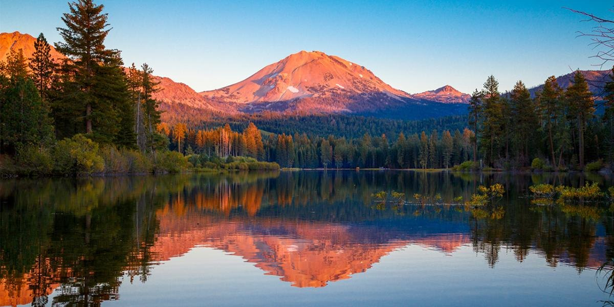

**National parks.** The long walk-in, the early start.

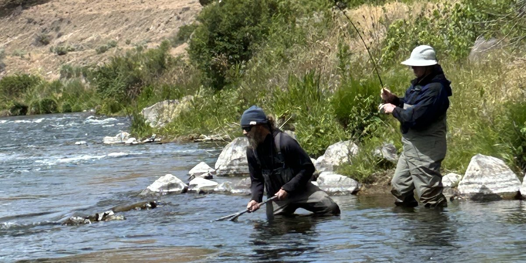

**Fly fishing.** Mostly an excuse to stand in cold water and think.

Curiosity about how small agents build big structures is the through-line. It started with animals and never really stopped.

**The crew.** Three dogs with three incompatible opinions about the office chair.

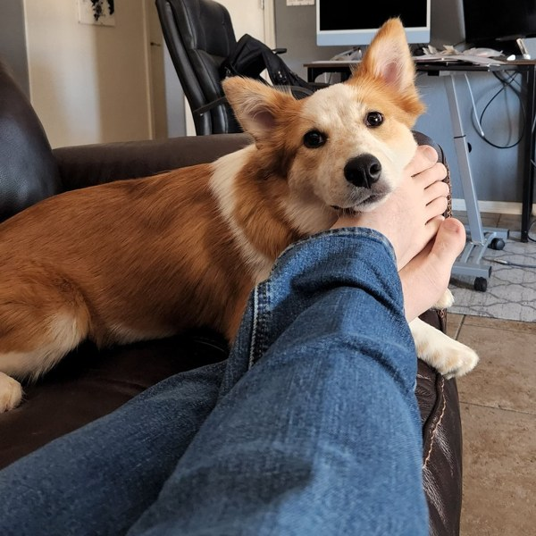

**Finn**

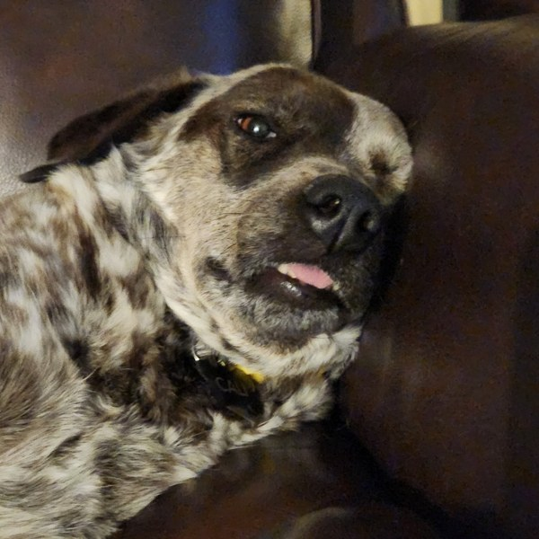

**Cali**

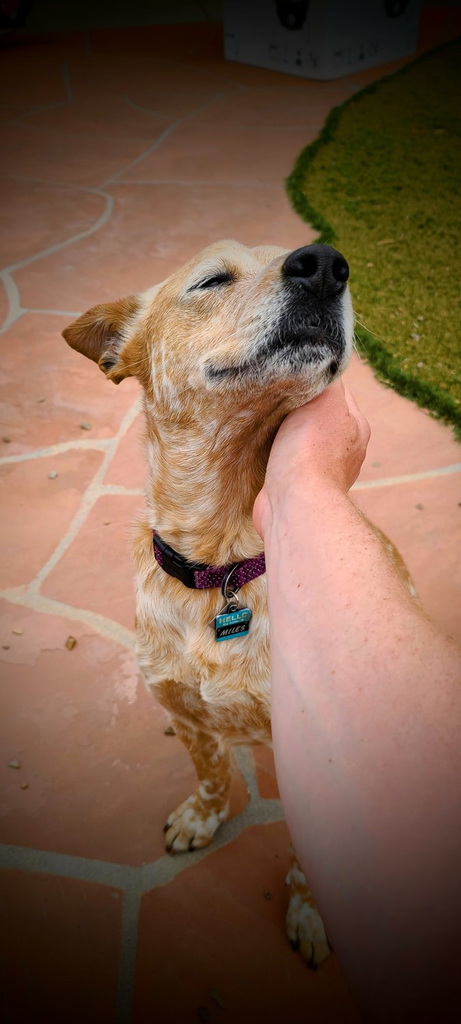

**Miles**

## How I got here

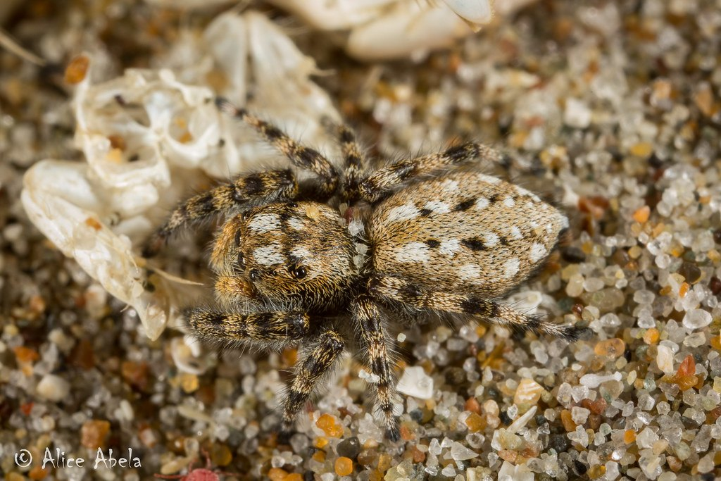

**Social spiders**

UCSB · Undergraduate

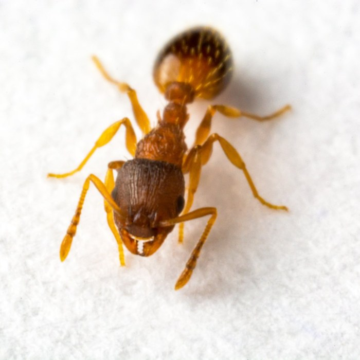

**Social insects**

Arizona · Ph.D.

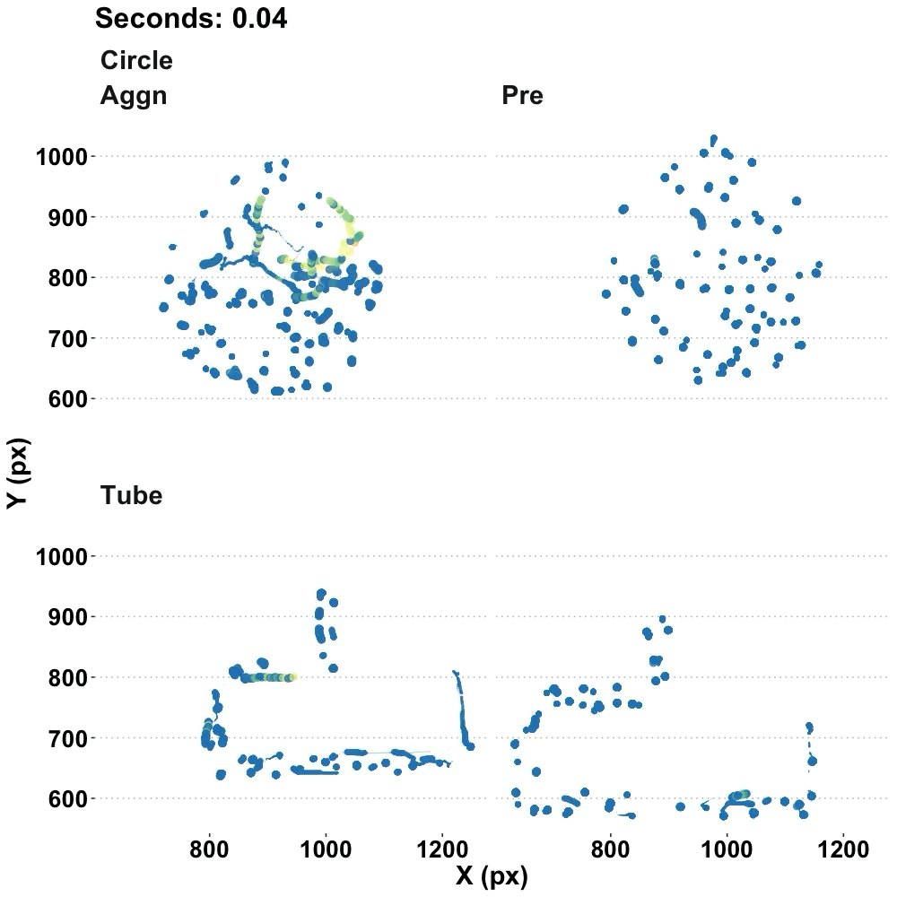

**Nest analytics**

Where the data turn began

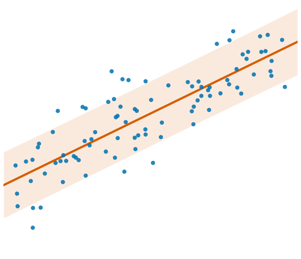

**Data science**

Arizona · College of Information Science

**The turn:** measuring *how ant colonies use the space they build* meant tracking hundreds of individuals for days at a time. The bottleneck stopped being the microscope and became the analysis, so I went to fix the analysis and never came back.

# Two research programs

**01** · Healthcare analytics: measurement you can trust

**02** · AI-assisted research workflows: pipelines that scale

## Healthcare: the question

**Does chronic pain distort depression screening?**

The PHQ-8 counts somatic symptoms: **sleep, fatigue, appetite, psychomotor slowing**. Those are also everyday features of chronic pain, which raises the worry of *criterion contamination*. The tool might be counting pain and recording it as depression.

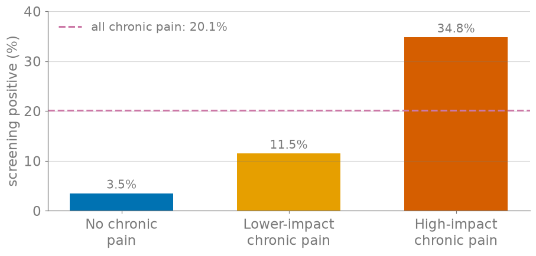

Figure 1: Positive PHQ-8 screens (≥10) by pain impact, 2019 NHIS (n = 30,983). Dashed line: all chronic pain combined (20.1%), which is the union of the two CP bars rather than a fourth group.

**The finding: it doesn’t.** The gap is real rather than an artifact of the instrument.

## Healthcare: why it’s trustworthy

| Check | No CP | CP |
| --- | --- | --- |
| Cronbach’s α | 0.82 | 0.85 |
| McDonald’s ω | 0.86 | 0.89 |
| CFI | 0.994 | 0.993 |
| TLI | 0.991 | 0.991 |

**Invariance holds** at the configural, metric, **and scalar** levels. **No differential item functioning.**

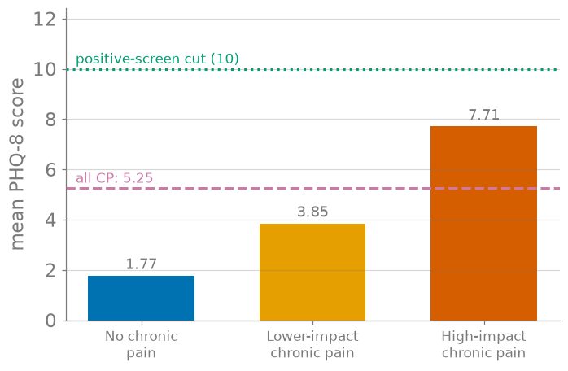

Figure 2: Mean PHQ-8 by pain impact. Even the high-impact mean (7.71) sits below the ≥10 screening cut point.

## AI workflows: the system

**3,681** state bills (OpenStates + LegiScan, 2017–) → **2,364 AI-relevant** (64%), 51 jurisdictions, **14-category** governance taxonomy, mean 2.86 categories per bill.

**Six-model ensemble, zero-shot.** Three Claude models (Sonnet, Opus, Haiku) and three open-source (Qwen-2.5-72B, Llama-3.1-70B/8B). F1-weighted majority vote, with confidence tiers from raw six-model agreement.

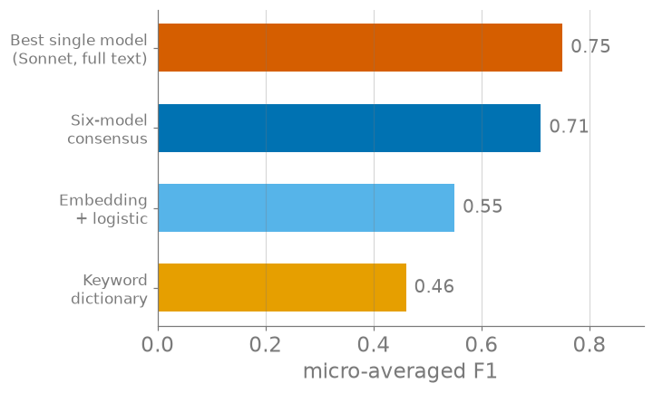

Figure 3: F1 on the n = 20 human gold set. The ensemble does *not* beat Sonnet alone. What it buys is calibrated confidence.

Honest caveat: the gold set is **n = 20, single-coder**. That fixes the *ordering* of methods, but not tight per-category intervals.

## AI workflows: what the data shows

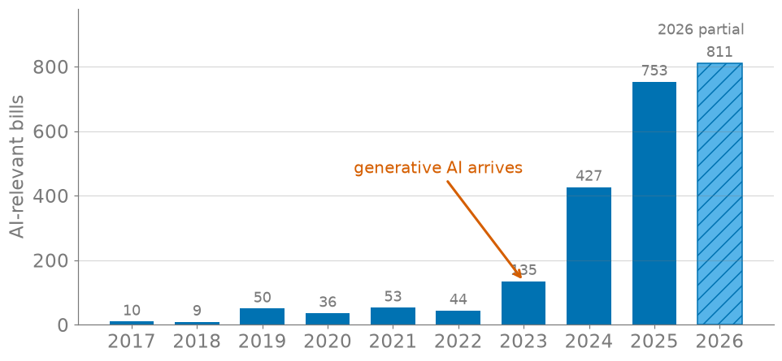

Figure 4: AI-relevant bills by year of first action. 2026 (hatched) is a partial year, with the corpus frozen 2026-07-10, and it has already passed all of 2025.

**Enactment: 17.7%** of 1,935 decided bills. Narrow bills pass: Education 22.9%, Criminal Use 22.8%. Accountability stalls: Private Right of Action 12.8%, Industry Use 12.8%, Taxes 5.7%.

Cox model (2,250 bills, 342 events): sponsor count **HR 1.23**; Disclosure **HR 0.80** and Private Right of Action **HR 0.79** *slow* enactment. The mechanisms with teeth are the ones that stall.

# INFO 521

**Probabilistic and from-scratch** · **healthcare-grounded** · **reproducible by design**

## Learning outcomes

By the end of this course, you will be able to:

1. **Identify and evaluate** machine-learning approaches appropriate for regression, classification, clustering, and dimensionality-reduction problems.
2. **Implement** machine-learning algorithms in Python using industry-standard tools and workflows.
3. **Compare and interpret** model performance using appropriate evaluation metrics, validation techniques, and statistical reasoning.
4. **Apply** machine-learning methods to real-world datasets to develop predictive and descriptive models.
5. **Communicate** results, limitations, and recommendations through written, visual, and technical presentations.

## The seven-module arc

*loss → likelihood → posterior → approximation → discovery*

|  | Module | The idea |
| --- | --- | --- |
| **M1** | Linear Least Squares | the model, the normal equations |
| **M2** | Generalization | CV, bias–variance, ridge |
| **M3** | Likelihood & MLE | least squares, re-earned |
| **M4** | Bayesian Inference | priors, posteriors, conjugacy |
| **M5** | Approximate Inference | logistic + Newton, Laplace, MCMC |
| **M6** | SVM & Clustering | max-margin, k-means, GMM + EM |
| **M7** | PCA | eigen-decomposition of the covariance |

**One object runs through all of it: X**ᵀ**X.** The least-squares bowl (M1), the likelihood’s curvature and Fisher information (M3), the Laplace posterior covariance (M5), the covariance you eigen-decompose (M7).

## How the course works

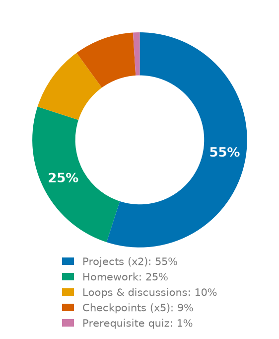

Figure 5: Grade weighting. Projects and homework together make up 80%, the work that looks most like real practice.

- **Specs grading.** Work is **Pass** or **Not-Yet**, never partial credit. Autograded correctness resubmits **without limit**; human-reviewed components draw on a small pool of revision tokens.
- **Two projects, one seam.** *One Problem, Three Lenses* → *From Inference to Discovery*. Part 1 closes on the **conjugate Gaussian posterior**; Part 2 opens by **binarizing the outcome to break conjugacy**, which is exactly what forces approximate inference.
- **Interactive weekly activities.** Each module ships a browser tool you use in lecture and again in the peer loop.
- **Peer-engagement loops, four stages:** tool + mastery check → reflection → review **every** teammate → respond and revise. Credit needs all four.

## Where this lands

The clinical data you will model in INFO 521 is **the same kind of data I study**: national health survey data, self-reported instruments, real measurement error, and consequences attached to the answer.

So the questions this course trains you to ask are not academic:

- Is the gap I measured **real**, or an artifact of the instrument?
- Does my model do better than the **simplest thing that could work**?
- What does my method get wrong, and **who does that cost**?

Every method in this course is a way of being **honest about uncertainty**.

**Greg Chism** · gchism@arizona.edu · College of Information Science, University of Arizona